# Contract Exercised Options

Greg Sanders

# Modeling Likelihood of Contract Termination, Ceiling Breach, or Exercised Option

# Setup

```
##
## arm (Version 1.10-1, built: 2018-4-12)
```

```
## Working directory is C:/Users/gsand/Repositories/Services/analysis
```

```
##  Hlavac, Marek (2018). stargazer: Well-Formatted Regression and Summary Statistics Tables.
```

```
##  R package version 5.2.2. https://CRAN.R-project.org/package=stargazer
```

```
## dummies-1.5.6 provided by Decision Patterns
```

## Load Data

First we load the data. The dataset used is a U.S. Defense Contracting dataset derived from FPDS.

```r
load(file="..//data//clean//def_sample.Rdata")
```

The sample is created by including the entirity of the ARRA and Disaster datasets, as well as 100,000 records each from the OCO datase and another 100,000 from all remaining records.

# Study Variables

## Services Complexity

Expectation: Higher service complexity would make work more demanding and thus raises the risks of negative contracting outcomes, namely the likelihood of cost ceiling breaches and terminations increases and the likelihood exercised options decraeses.

### 01A NAICS Salary

Expectation: Given the fact that one source for higher salaries is the difficulty of the work and the experience and education required, as average NAICS salary increases (decreases), the likelihood of cost ceiling breaches and terminations increases (decreases) and exercised options decreases (increases).

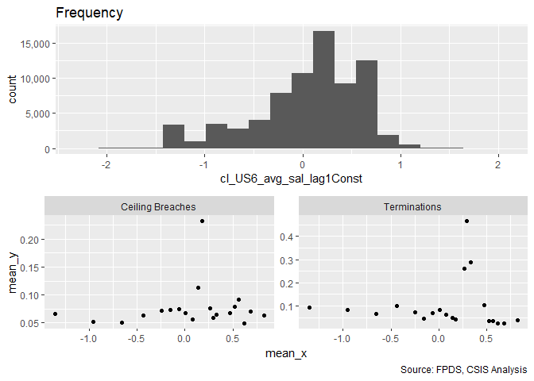

```r
 # !is.na(def_serv$cl_US6_avg_sal_lag1)&
 #  !is.na(def_serv$cl_CFTE)&
 #  !is.na(def_serv$c_pPBSC)&
 #  !is.na(def_serv$c_pOffPSC)&
 #  !is.na(def_serv$c_pairHist)&
 #  !is.na(def_serv$cl_pairCA)&

summary_continuous_plot(serv_opt,"cl_US6_avg_sal_lag1Const")
```

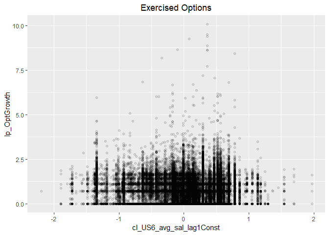

```r
#Scatter Plot of p_Opt_01A
ggplot(serv_opt, aes(x=cl_US6_avg_sal_lag1Const, y=lp_OptGrowth)) + geom_point(alpha = 0.1) + ggtitle('Exercised Options') + theme(plot.title = element_text(hjust = 0.5))
```

```r
#Model
n_Opt_01A <- glm (data=serv_opt,
                 ln_OptGrowth ~ cl_US6_avg_sal_lag1Const)
display(n_Opt_01A)
```

```
## glm(formula = ln_OptGrowth ~ cl_US6_avg_sal_lag1Const, data = serv_opt)
##                          coef.est coef.se
## (Intercept)              7.23     0.02
## cl_US6_avg_sal_lag1Const 0.19     0.04
## ---
##   n = 74162, k = 2
##   residual deviance = 2585000.9, null deviance = 2585789.3 (difference = 788.4)
##   overdispersion parameter = 34.9
##   residual sd is sqrt(overdispersion) = 5.90
```

```r
p_Opt_01A <- glm(data=serv_opt,
                        lp_OptGrowth ~ cl_US6_avg_sal_lag1Const)


#Plot residuals versus fitted
stargazer::stargazer(n_Opt_01A,p_Opt_01A,type="text",
                       digits=2)
```

```
##
## =====================================================
##                              Dependent variable:
##                          ----------------------------
##                           ln_OptGrowth  lp_OptGrowth
##                               (1)            (2)
## -----------------------------------------------------
## cl_US6_avg_sal_lag1Const    0.19***       -0.07***
##                              (0.04)        (0.005)
##
## Constant                    7.23***        0.65***
##                              (0.02)        (0.003)
##
## -----------------------------------------------------
## Observations                 74,162        74,162
## Log Likelihood            -236,915.50    -77,199.78
## Akaike Inf. Crit.          473,834.90    154,403.60
## =====================================================
## Note:                     *p<0.1; **p<0.05; ***p<0.01
```

Individually, except for terminations (which is not significant), expectations are matched for ceiing breaches and exercised options, as higher average salaries estimate a higher risk of ceiling breaches and lower possibility of exercised options.

### 01B Invoice Rate

Expectation: The invoice rate approximates how much the government is charged annually for each comparable full-time employees who are supporting the service contracts. A higher invoice rate indicates a more complex service. As invoice rate increases (decreases), the likelihood of cost ceiling breaches and terminations increases (decreases), and exercised options decrease (increase).

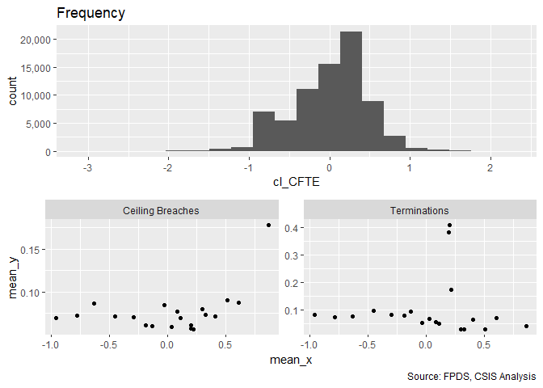

```r
 # !is.na(def_serv$cl_US6_avg_sal_lag1)&
 #  !is.na(def_serv$cl_CFTE)&
 #  !is.na(def_serv$c_pPBSC)&
 #  !is.na(def_serv$c_pOffPSC)&
 #  !is.na(def_serv$c_pairHist)&
 #  !is.na(def_serv$cl_pairCA)&

summary_continuous_plot(serv_opt,"cl_CFTE")
```

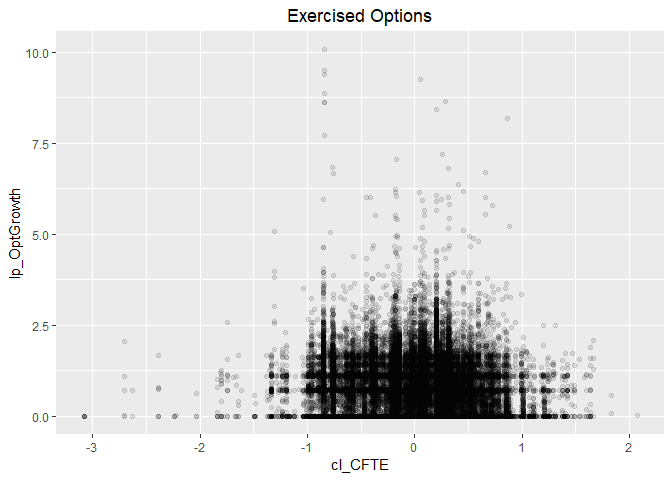

```r
#Scatter Plot
ggplot(serv_opt, aes(x=cl_CFTE, y=lp_OptGrowth)) + geom_point(alpha = 0.1) + ggtitle('Exercised Options') + theme(plot.title = element_text(hjust = 0.5))
```

```r
#Model
n_Opt_01B <- glm (data=serv_opt,
                 ln_OptGrowth ~ cl_CFTE)
display(n_Opt_01B)
```

```
## glm(formula = ln_OptGrowth ~ cl_CFTE, data = serv_opt)
##             coef.est coef.se
## (Intercept)  7.25     0.02
## cl_CFTE     -0.52     0.05
## ---
##   n = 74162, k = 2
##   residual deviance = 2581554.0, null deviance = 2585789.3 (difference = 4235.2)
##   overdispersion parameter = 34.8
##   residual sd is sqrt(overdispersion) = 5.90
```

```r
p_Opt_01B <- glm(data=serv_opt,
                        lp_OptGrowth ~ cl_CFTE)



#Plot residuals versus fitted
  stargazer::stargazer(n_Opt_01A,n_Opt_01B,

                       p_Opt_01A,p_Opt_01B,
                       type="text",
                       digits=2)
```

```
##
## ======================================================================
##                                       Dependent variable:
##                          ---------------------------------------------
##                               ln_OptGrowth           lp_OptGrowth
##                              (1)         (2)        (3)        (4)
## ----------------------------------------------------------------------
## cl_US6_avg_sal_lag1Const   0.19***                -0.07***
##                            (0.04)                 (0.005)
##
## cl_CFTE                               -0.52***               -0.14***
##                                        (0.05)                 (0.01)
##
## Constant                   7.23***     7.25***    0.65***    0.65***
##                            (0.02)      (0.02)     (0.003)    (0.003)
##
## ----------------------------------------------------------------------
## Observations               74,162      74,162      74,162     74,162
## Log Likelihood           -236,915.50 -236,866.00 -77,199.78 -77,007.63
## Akaike Inf. Crit.        473,834.90  473,736.00  154,403.60 154,019.30
## ======================================================================
## Note:                                      *p<0.1; **p<0.05; ***p<0.01
```

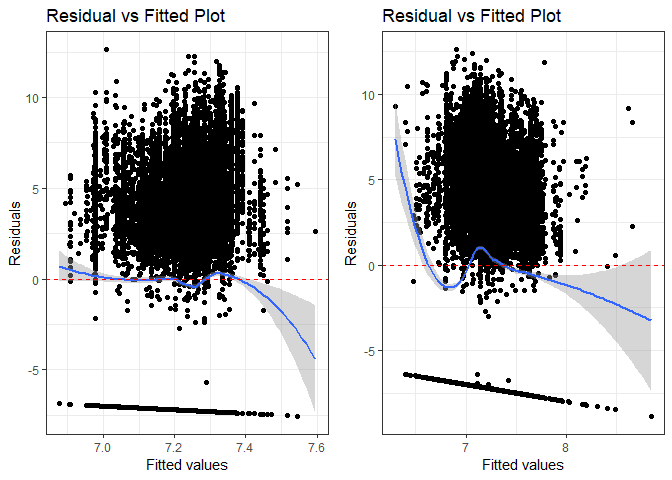

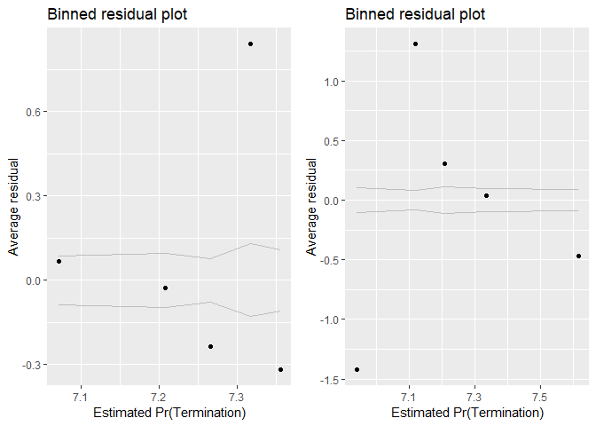

```r
summary_residual_compare(n_Opt_01A,n_Opt_01B, skip_vif = TRUE)
```

When considered alone, expectations are matched for ceiling breaches and exercised options, as higher invoice rate estimates a higher risk of ceiling breaches and lower possibility of exercised options. No significant relationship between invoice rate and terminations.

### 01C Service Complexity

Expectation: Collectively, the higher average salary and invoice rate (more complexity is indicated), the higher risk of ceiling breaches and terminations and the less exercised options there would be. Also we expect the result of combined model would be the same as individual models.

```r
 #  !is.na(def_serv$c_pPBSC)&
 #  !is.na(def_serv$c_pOffPSC)&
 #  !is.na(def_serv$c_pairHist)&
 #  !is.na(def_serv$cl_pairCA)&


#Model
n_Opt_01C <- glm (data=serv_opt,
                 ln_OptGrowth ~ cl_US6_avg_sal_lag1Const + cl_CFTE)
glmer_examine(n_Opt_01C)
```

```
## cl_US6_avg_sal_lag1Const                  cl_CFTE
##                 1.432874                 1.432874
```

```r
p_Opt_01C <- glm(data=serv_opt,
                        lp_OptGrowth ~ cl_US6_avg_sal_lag1Const +  cl_CFTE)

glmer_examine(p_Opt_01C)
```

```
## cl_US6_avg_sal_lag1Const                  cl_CFTE
##                 1.432874                 1.432874
```

```r
#Plot residuals versus fitted
stargazer::stargazer(n_Opt_01A,n_Opt_01B,n_Opt_01C,

                       p_Opt_01A,p_Opt_01B,p_Opt_01C,
                       type="text",
                       digits=2)
```

```
##
## =============================================================================================
##                                                  Dependent variable:
##                          --------------------------------------------------------------------
##                                     ln_OptGrowth                       lp_OptGrowth
##                              (1)         (2)         (3)        (4)        (5)        (6)
## ---------------------------------------------------------------------------------------------
## cl_US6_avg_sal_lag1Const   0.19***                 0.61***    -0.07***              -0.01***
##                            (0.04)                  (0.05)     (0.005)                (0.01)
##
## cl_CFTE                               -0.52***    -0.92***               -0.14***   -0.13***
##                                        (0.05)      (0.06)                 (0.01)     (0.01)
##
## Constant                   7.23***     7.25***     7.22***    0.65***    0.65***    0.65***
##                            (0.02)      (0.02)      (0.02)     (0.003)    (0.003)    (0.003)
##
## ---------------------------------------------------------------------------------------------
## Observations               74,162      74,162      74,162      74,162     74,162     74,162
## Log Likelihood           -236,915.50 -236,866.00 -236,782.00 -77,199.78 -77,007.63 -77,004.24
## Akaike Inf. Crit.        473,834.90  473,736.00  473,570.00  154,403.60 154,019.30 154,014.50
## =============================================================================================
## Note:                                                             *p<0.1; **p<0.05; ***p<0.01
```

```r
  summary_residual_compare(n_Opt_01A,n_Opt_01C)
```

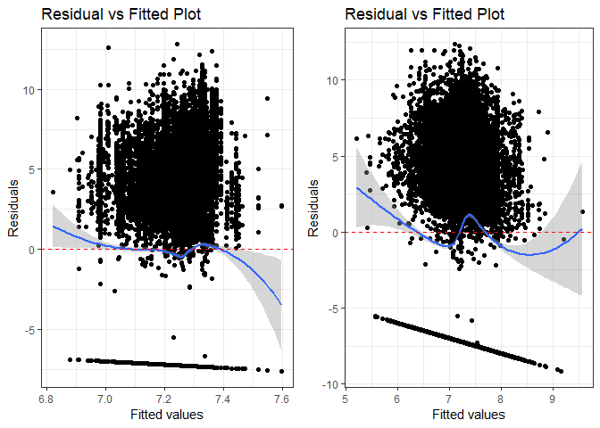

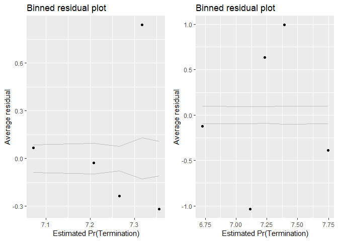

[output not shown]

```r
  summary_residual_compare(n_Opt_01B,n_Opt_01C)
```

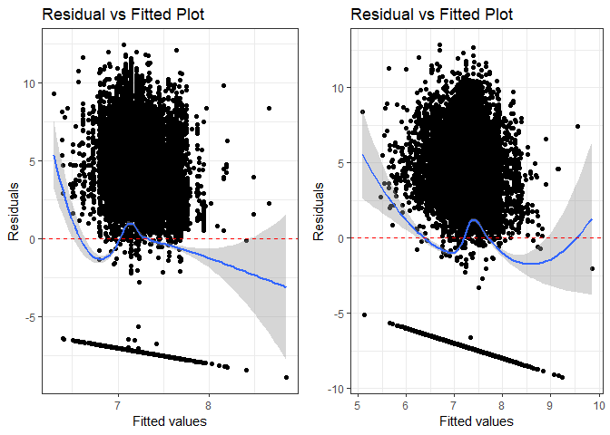

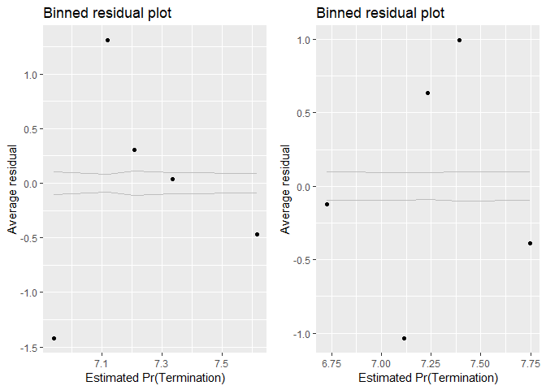

```
## [[1]]
##        model deviance null.deviance difference
## 1 model1_old  2581554       2585789   4235.246
## 2 model1_new  2575713       2585789  10076.505
##
## [[2]]
## cl_US6_avg_sal_lag1Const                  cl_CFTE
##                 1.432874                 1.432874
```

Both average salary and invoiced rate have a not inconsiderable VIF but one well within bounds, suggesting that the variance of the estimated coefficients is not evidently inflated and none of them are highly correlated with each other.

Both individually and pair-wise, higher average salary and invoiced rate estimate higher possibility of cost ceiling breaches and lower likelihood of exercised options as expected. But the termination expectation is not supported or not significant for two measures of service complexity resepctively.

## Office Capacity

### 02A: Performance Based Services

Expectation: Performance-based services contracting ties a portion of a contractor’s payment, contract extensions, or contract renewals to the achievement of specific, measurable performance standards and requirements, which encourages better contracting results. PBSC has the potential to reduce terminations and ceiling breaches and bring more possibility of exercised options.

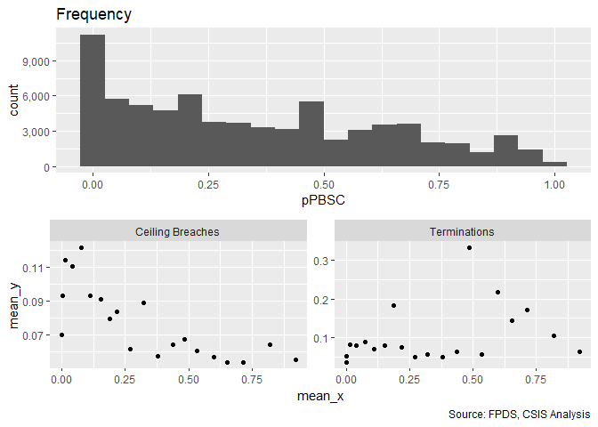

```r
summary_continuous_plot(serv_opt,"pPBSC")
```

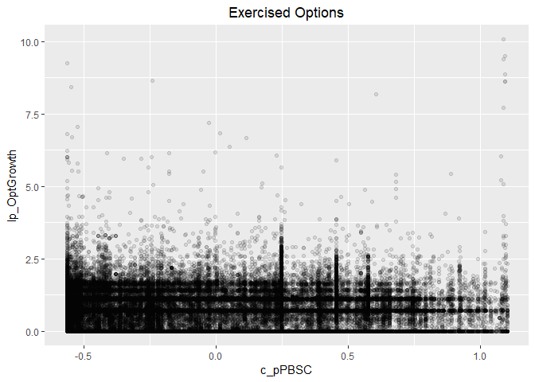

```r
#Scatter Plot
ggplot(serv_opt, aes(x=c_pPBSC, y=lp_OptGrowth)) + geom_point(alpha = 0.1) + ggtitle('Exercised Options') + theme(plot.title = element_text(hjust = 0.5))
```

```r
#Model
n_Opt_02A <- glm (data=serv_opt,
                 ln_OptGrowth ~ c_pPBSC)
display(n_Opt_02A)
```

```
## glm(formula = ln_OptGrowth ~ c_pPBSC, data = serv_opt)
##             coef.est coef.se
## (Intercept)  7.25     0.02
## c_pPBSC     -0.57     0.05
## ---
##   n = 74162, k = 2
##   residual deviance = 2580627.9, null deviance = 2585789.3 (difference = 5161.4)
##   overdispersion parameter = 34.8
##   residual sd is sqrt(overdispersion) = 5.90
```

```r
p_Opt_02A <- glm(data=serv_opt,
                        lp_OptGrowth ~ c_pPBSC)

display(p_Opt_02A)
```

```
## glm(formula = lp_OptGrowth ~ c_pPBSC, data = serv_opt)
##             coef.est coef.se
## (Intercept)  0.65     0.00
## c_pPBSC     -0.05     0.01
## ---
##   n = 74162, k = 2
##   residual deviance = 34911.7, null deviance = 34944.5 (difference = 32.8)
##   overdispersion parameter = 0.5
##   residual sd is sqrt(overdispersion) = 0.69
```

```r
#Plot residuals versus fitted
stargazer::stargazer(n_Opt_01C,n_Opt_02A,

                       p_Opt_01C,p_Opt_02A,
                       type="text",
                       digits=2)
```

```
##
## ======================================================================
##                                       Dependent variable:
##                          ---------------------------------------------
##                               ln_OptGrowth           lp_OptGrowth
##                              (1)         (2)        (3)        (4)
## ----------------------------------------------------------------------
## cl_US6_avg_sal_lag1Const   0.61***                -0.01***
##                            (0.05)                  (0.01)
##
## cl_CFTE                   -0.92***                -0.13***
##                            (0.06)                  (0.01)
##
## c_pPBSC                               -0.57***               -0.05***
##                                        (0.05)                 (0.01)
##
## Constant                   7.22***     7.25***    0.65***    0.65***
##                            (0.02)      (0.02)     (0.003)    (0.003)
##
## ----------------------------------------------------------------------
## Observations               74,162      74,162      74,162     74,162
## Log Likelihood           -236,782.00 -236,852.70 -77,004.24 -77,294.40
## Akaike Inf. Crit.        473,570.00  473,709.30  154,014.50 154,592.80
## ======================================================================
## Note:                                      *p<0.1; **p<0.05; ***p<0.01
```

### 02B: No.Office PSC History

Expectation: The increasing share of contracting office obligations for a given service indicates high capcaity in that area, lower likelihood of cost ceiling breaches and termination and higher likelihood of exercised options are expected to be observed.

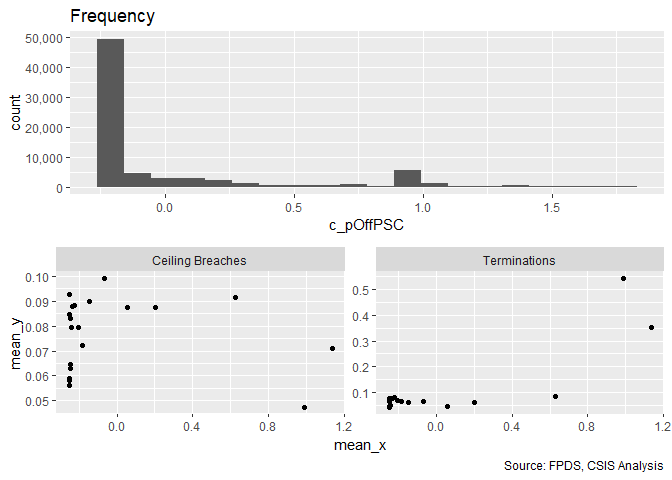

```r
 # !is.na(def_serv$cl_US6_avg_sal_lag1)&
 #  !is.na(def_serv$cl_CFTE)&
 #  !is.na(def_serv$c_pPBSC)&
 #  !is.na(def_serv$c_pOffPSC)&
 #  !is.na(def_serv$c_pairHist)&
 #  !is.na(def_serv$cl_pairCA)&

summary_continuous_plot(serv_opt,"c_pOffPSC")
```

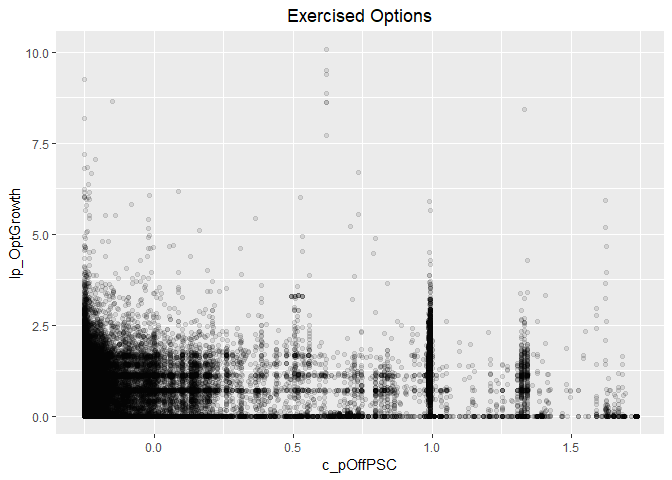

```r
#Scatter Plot
ggplot(serv_opt, aes(x=c_pOffPSC, y=lp_OptGrowth)) + geom_point(alpha = 0.1) + ggtitle('Exercised Options') + theme(plot.title = element_text(hjust = 0.5))
```

```r
#Model
n_Opt_02B <- glm (data=serv_opt,
                 ln_OptGrowth ~ c_pOffPSC)
display(n_Opt_02B)
```

```
## glm(formula = ln_OptGrowth ~ c_pOffPSC, data = serv_opt)
##             coef.est coef.se
## (Intercept)  7.23     0.02
## c_pOffPSC   -0.36     0.05
## ---
##   n = 74162, k = 2
##   residual deviance = 2584052.8, null deviance = 2585789.3 (difference = 1736.5)
##   overdispersion parameter = 34.8
##   residual sd is sqrt(overdispersion) = 5.90
```

```r
p_Opt_02B <- glm(data=serv_opt,
                        lp_OptGrowth ~ c_pOffPSC)

display(p_Opt_02B)
```

```
## glm(formula = lp_OptGrowth ~ c_pOffPSC, data = serv_opt)
##             coef.est coef.se
## (Intercept) 0.65     0.00
## c_pOffPSC   0.12     0.01
## ---
##   n = 74162, k = 2
##   residual deviance = 34757.8, null deviance = 34944.5 (difference = 186.7)
##   overdispersion parameter = 0.5
##   residual sd is sqrt(overdispersion) = 0.68
```

```r
#Plot residuals versus fitted
stargazer::stargazer(n_Opt_01C,n_Opt_02A,n_Opt_02B,

                       p_Opt_01C,p_Opt_02A,p_Opt_02B,
                       type="text",
                       digits=2)
```

```
##
## =============================================================================================
##                                                  Dependent variable:
##                          --------------------------------------------------------------------
##                                     ln_OptGrowth                       lp_OptGrowth
##                              (1)         (2)         (3)        (4)        (5)        (6)
## ---------------------------------------------------------------------------------------------
## cl_US6_avg_sal_lag1Const   0.61***                            -0.01***
##                            (0.05)                              (0.01)
##
## cl_CFTE                   -0.92***                            -0.13***
##                            (0.06)                              (0.01)
##
## c_pPBSC                               -0.57***                           -0.05***
##                                        (0.05)                             (0.01)
##
## c_pOffPSC                                         -0.36***                          0.12***
##                                                    (0.05)                            (0.01)
##
## Constant                   7.22***     7.25***     7.23***    0.65***    0.65***    0.65***
##                            (0.02)      (0.02)      (0.02)     (0.003)    (0.003)    (0.003)
##
## ---------------------------------------------------------------------------------------------
## Observations               74,162      74,162      74,162      74,162     74,162     74,162
## Log Likelihood           -236,782.00 -236,852.70 -236,901.90 -77,004.24 -77,294.40 -77,130.56
## Akaike Inf. Crit.        473,570.00  473,709.30  473,807.70  154,014.50 154,592.80 154,265.10
## =============================================================================================
## Note:                                                             *p<0.1; **p<0.05; ***p<0.01
```

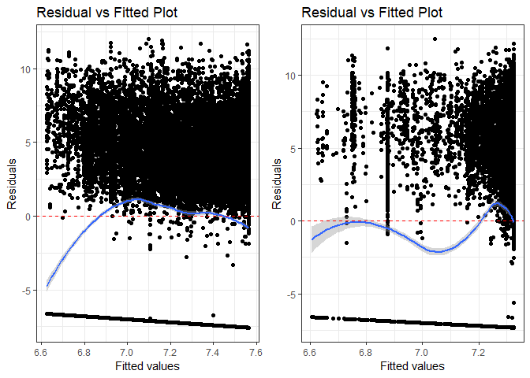

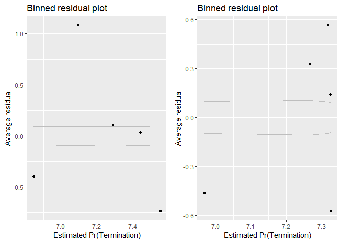

```r
summary_residual_compare(n_Opt_02A,n_Opt_02B, skip_vif = TRUE)
```

When considering number of contracting office obligations for a given service alone, expectation was only fulfilled for options growth.

### 02C: Office Capacity

Expectation: Collaberactively, the larger share of PBSC and contracting office obligations for a given service, the less risk of ceiling breaches and terminations and the more exercised options there would be. Also we expect the results of combined model would be the same as two individual models above.

```r
#Model
n_Opt_02C <- glm (data=serv_opt,
                 ln_OptGrowth ~ c_pPBSC+c_pOffPSC)
glmer_examine(n_Opt_02C)
```

```
##   c_pPBSC c_pOffPSC
##  1.072831  1.072831
```

```r
p_Opt_02C <- glm(data=serv_opt,
                        lp_OptGrowth ~ c_pPBSC+c_pOffPSC)

glmer_examine(p_Opt_02C)
```

```
##   c_pPBSC c_pOffPSC
##  1.072831  1.072831
```

```r
#Plot residuals versus fitted
stargazer::stargazer(n_Opt_01C,n_Opt_02A,n_Opt_02B,n_Opt_02C,

                       p_Opt_01C,p_Opt_02A,p_Opt_02B,p_Opt_02C,
                       type="text",
                       digits=2)
```

```
##
## ====================================================================================================================
##                                                              Dependent variable:
##                          -------------------------------------------------------------------------------------------
##                                           ln_OptGrowth                                  lp_OptGrowth
##                              (1)         (2)         (3)         (4)        (5)        (6)        (7)        (8)
## --------------------------------------------------------------------------------------------------------------------
## cl_US6_avg_sal_lag1Const   0.61***                                        -0.01***
##                            (0.05)                                          (0.01)
##
## cl_CFTE                   -0.92***                                        -0.13***
##                            (0.06)                                          (0.01)
##
## c_pPBSC                               -0.57***                -0.51***               -0.05***              -0.08***
##                                        (0.05)                  (0.05)                 (0.01)                (0.01)
##
## c_pOffPSC                                         -0.36***    -0.21***                          0.12***    0.14***
##                                                    (0.05)      (0.05)                            (0.01)     (0.01)
##
## Constant                   7.22***     7.25***     7.23***     7.24***    0.65***    0.65***    0.65***    0.65***
##                            (0.02)      (0.02)      (0.02)      (0.02)     (0.003)    (0.003)    (0.003)    (0.003)
##
## --------------------------------------------------------------------------------------------------------------------
## Observations               74,162      74,162      74,162      74,162      74,162     74,162     74,162     74,162
## Log Likelihood           -236,782.00 -236,852.70 -236,901.90 -236,844.50 -77,004.24 -77,294.40 -77,130.56 -77,031.69
## Akaike Inf. Crit.        473,570.00  473,709.30  473,807.70  473,695.10  154,014.50 154,592.80 154,265.10 154,069.40
## ====================================================================================================================
## Note:                                                                                    *p<0.1; **p<0.05; ***p<0.01
```

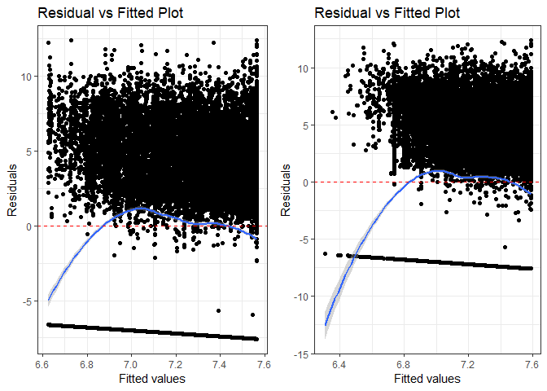

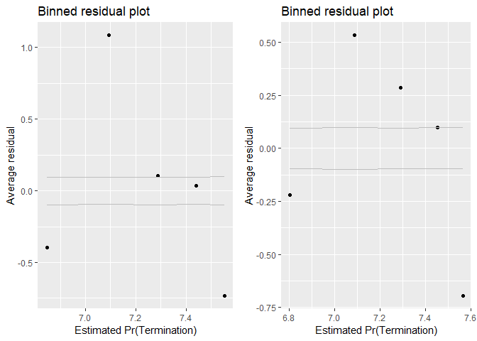

```
## [[1]]
##        model deviance null.deviance difference
## 1 model1_old  2580628       2585789   5161.424
## 2 model1_new  2580063       2585789   5726.600
##
## [[2]]
##   c_pPBSC c_pOffPSC
##  1.072831  1.072831
```

```r
summary_residual_compare(n_Opt_02A,n_Opt_02C)
```

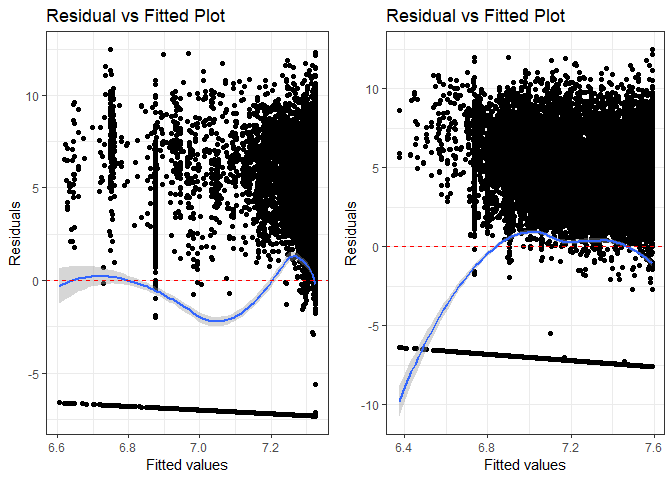

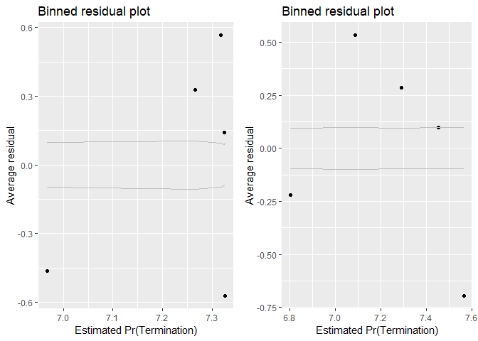

```
## [[1]]
##        model deviance null.deviance difference
## 1 model1_old  2584053       2585789   1736.477
## 2 model1_new  2580063       2585789   5726.600
##
## [[2]]
##   c_pPBSC c_pOffPSC
##  1.072831  1.072831
```

```r
summary_residual_compare(n_Opt_02B,n_Opt_02C)
```

No high correlation is observed between PBSC and Contract Office Obligations for PSC based on the vif score.

### 02D: Cumulative Model

Expectation: When all the four variables are combined into one model, same expectations are applied as individual ones. Per service complexity indicator increases, higher risk of ceiling breaches and terminations and less exercised options expected. Per office capacity indicator increases, lower risk of ceiling breaches and terminations and more exercised options expected.

```r
#Model
n_Opt_02D <- glm (data=serv_opt,
                 ln_OptGrowth ~ cl_US6_avg_sal_lag1Const + cl_CFTE+ c_pPBSC+c_pOffPSC)
glmer_examine(n_Opt_02D)
```

```
## cl_US6_avg_sal_lag1Const                  cl_CFTE                  c_pPBSC
##                 1.479918                 1.459804                 1.114917
##                c_pOffPSC
##                 1.120164
```

```r
p_Opt_02D <- glm(data=serv_opt,
                        lp_OptGrowth ~ cl_US6_avg_sal_lag1Const + cl_CFTE+ c_pPBSC+c_pOffPSC)

glmer_examine(p_Opt_02D)
```

```
## cl_US6_avg_sal_lag1Const                  cl_CFTE                  c_pPBSC
##                 1.479918                 1.459804                 1.114917
##                c_pOffPSC
##                 1.120164
```

```r
#Plot residuals versus fitted
stargazer::stargazer(n_Opt_01C,n_Opt_02C,n_Opt_02D,

                       p_Opt_01C,p_Opt_02C,p_Opt_02D,
                       type="text",
                       digits=2)
```

```
##
## =============================================================================================
##                                                  Dependent variable:
##                          --------------------------------------------------------------------
##                                     ln_OptGrowth                       lp_OptGrowth
##                              (1)         (2)         (3)        (4)        (5)        (6)
## ---------------------------------------------------------------------------------------------
## cl_US6_avg_sal_lag1Const   0.61***                 0.71***    -0.01***              -0.03***
##                            (0.05)                  (0.05)      (0.01)                (0.01)
##
## cl_CFTE                   -0.92***                -0.82***    -0.13***              -0.14***
##                            (0.06)                  (0.06)      (0.01)                (0.01)
##
## c_pPBSC                               -0.51***    -0.52***               -0.08***   -0.05***
##                                        (0.05)      (0.05)                 (0.01)     (0.01)
##
## c_pOffPSC                             -0.21***    -0.24***               0.14***    0.17***
##                                        (0.05)      (0.05)                 (0.01)     (0.01)
##
## Constant                   7.22***     7.24***     7.22***    0.65***    0.65***    0.65***
##                            (0.02)      (0.02)      (0.02)     (0.003)    (0.003)    (0.003)
##
## ---------------------------------------------------------------------------------------------
## Observations               74,162      74,162      74,162      74,162     74,162     74,162
## Log Likelihood           -236,782.00 -236,844.50 -236,701.90 -77,004.24 -77,031.69 -76,611.39
## Akaike Inf. Crit.        473,570.00  473,695.10  473,413.90  154,014.50 154,069.40 153,232.80
## =============================================================================================
## Note:                                                             *p<0.1; **p<0.05; ***p<0.01
```

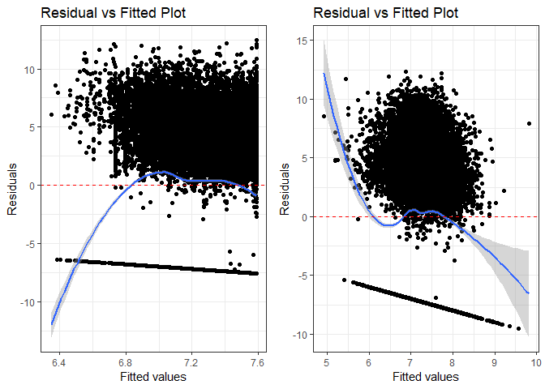

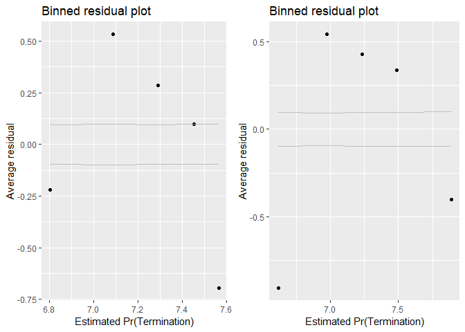

```
## [[1]]
##        model deviance null.deviance difference
## 1 model1_old  2580063       2585789    5726.60
## 2 model1_new  2570160       2585789   15629.63
##
## [[2]]
## cl_US6_avg_sal_lag1Const                  cl_CFTE                  c_pPBSC
##                 1.479918                 1.459804                 1.114917
##                c_pOffPSC
##                 1.120164
```

```r
summary_residual_compare(n_Opt_02C,n_Opt_02D)
```

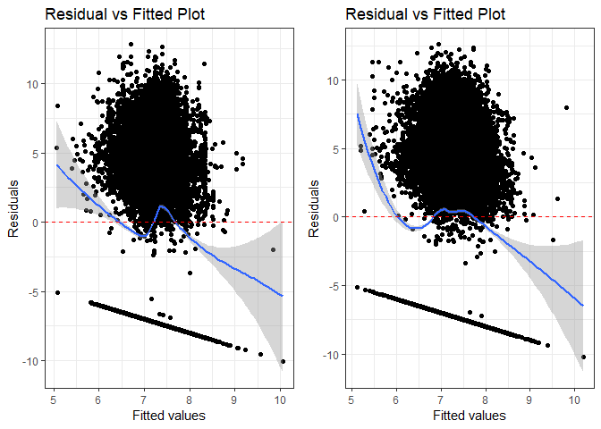

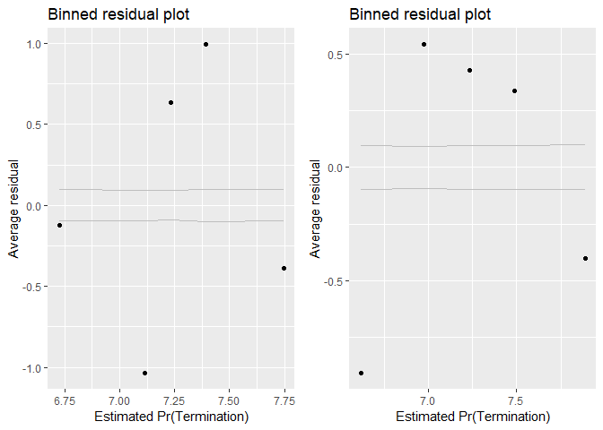

```
## [[1]]
##        model deviance null.deviance difference
## 1 model1_old  2575713       2585789   10076.50
## 2 model1_new  2570160       2585789   15629.63
##
## [[2]]
## cl_US6_avg_sal_lag1Const                  cl_CFTE                  c_pPBSC
##                 1.479918                 1.459804                 1.114917
##                c_pOffPSC
##                 1.120164
```

```r
summary_residual_compare(n_Opt_01C,n_Opt_02D)
```

No high correlation is observed among all of the 4 predictors (average salary, invoiced rate, PBSC and Contract Office Obligations for PSC) so far based on the vif score. When all measures for sevice complexity and office capacity are combined, per dependent variable:

1. Ceiling Breaches: All variables remain the same within each subgroup (Services Complexity and Office Capacity). Except for Contract office obligations for PSC, the results of other varibles matched with the expectation for ceiling breaches so far.
2. Terminations: Except for Contract office obligations for PSC, the rest of variables didn’t show significant relationships with Termination. The only significant relationship between Contract office obligations for PSC and Temrination didn’t match the expectation.
3. Exercised Options: Except for PBSC, all other three variables are associated with exercised options as expected.

## Office-Vendor Relationship

### 03A: Pair History

Expactation: The number of past years of the relationship between the contracting office or the contractors with a single transaction in a given fiscal year enough to qualify, namely, pair history increases (decreases), the likelihood of cost ceiling breaches and terminations decreases (increases) and the exercised options increase (decrease) for that partnership.

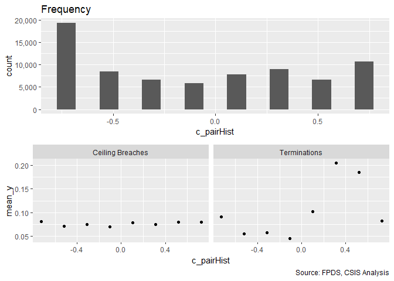

```
## [[1]]
##
## -0.727331277356926 -0.519773791968938  -0.31221630658095
##              19364               8401               6643
## -0.104658821192962  0.102898664195026  0.310456149583014
##               5767               7792               8954
##  0.518013634971002   0.72557112035899
##               6584              10657
##
## [[2]]
##
##                       None Ceiling Breach
##   -0.727331277356926 17798           1566
##   -0.519773791968938  7806            595
##   -0.31221630658095   6144            499
##   -0.104658821192962  5363            404
##   0.102898664195026   7178            614
##   0.310456149583014   8283            671
##   0.518013634971002   6060            524
##   0.72557112035899    9811            846
##
## [[3]]
##
##                          0     1
##   -0.727331277356926 17609  1755
##   -0.519773791968938  7935   466
##   -0.31221630658095   6259   384
##   -0.104658821192962  5509   258
##   0.102898664195026   6992   800
##   0.310456149583014   7116  1838
##   0.518013634971002   5365  1219
##   0.72557112035899    9777   880
```

```r
 # !is.na(def_serv$cl_US6_avg_sal_lag1)&
 #  !is.na(def_serv$cl_CFTE)&
 #  !is.na(def_serv$c_pPBSC)&
 #  !is.na(def_serv$c_pOffPSC)&
 #  !is.na(def_serv$c_pairHist)&
 #  !is.na(def_serv$cl_pairCA)&

summary_discrete_plot(serv_opt,"c_pairHist")
```

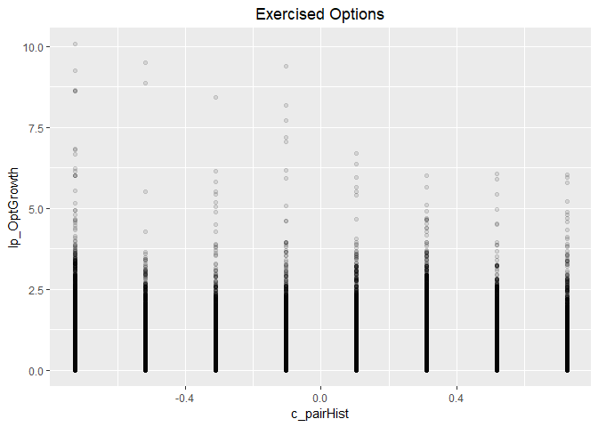

```r
#Scatter Plot
ggplot(serv_opt, aes(x=c_pairHist, y=lp_OptGrowth)) + geom_point(alpha = 0.1) + ggtitle('Exercised Options') + theme(plot.title = element_text(hjust = 0.5))
```

```r
#Model
n_Opt_03A <- glm (data=serv_opt,
                 ln_OptGrowth ~ c_pairHist)
display(n_Opt_03A)
```

```
## glm(formula = ln_OptGrowth ~ c_pairHist, data = serv_opt)
##             coef.est coef.se
## (Intercept)  7.19     0.02
## c_pairHist  -0.61     0.04
## ---
##   n = 74162, k = 2
##   residual deviance = 2578099.2, null deviance = 2585789.3 (difference = 7690.0)
##   overdispersion parameter = 34.8
##   residual sd is sqrt(overdispersion) = 5.90
```

```r
p_Opt_03A <- glm(data=serv_opt,
                        lp_OptGrowth ~ c_pairHist)

display(p_Opt_03A)
```

```
## glm(formula = lp_OptGrowth ~ c_pairHist, data = serv_opt)
##             coef.est coef.se
## (Intercept)  0.64     0.00
## c_pairHist  -0.04     0.00
## ---
##   n = 74162, k = 2
##   residual deviance = 34906.2, null deviance = 34944.5 (difference = 38.3)
##   overdispersion parameter = 0.5
##   residual sd is sqrt(overdispersion) = 0.69
```

```r
#Plot residuals versus fitted
  stargazer::stargazer(n_Opt_02D,n_Opt_03A,

                       p_Opt_02D,p_Opt_03A,
                       type="text",
                       digits=2)
```

```
##
## ======================================================================
##                                       Dependent variable:
##                          ---------------------------------------------
##                               ln_OptGrowth           lp_OptGrowth
##                              (1)         (2)        (3)        (4)
## ----------------------------------------------------------------------
## cl_US6_avg_sal_lag1Const   0.71***                -0.03***
##                            (0.05)                  (0.01)
##
## cl_CFTE                   -0.82***                -0.14***
##                            (0.06)                  (0.01)
##
## c_pPBSC                   -0.52***                -0.05***
##                            (0.05)                  (0.01)
##
## c_pOffPSC                 -0.24***                0.17***
##                            (0.05)                  (0.01)
##
## c_pairHist                            -0.61***               -0.04***
##                                        (0.04)                (0.005)
##
## Constant                   7.22***     7.19***    0.65***    0.64***
##                            (0.02)      (0.02)     (0.003)    (0.003)
##
## ----------------------------------------------------------------------
## Observations               74,162      74,162      74,162     74,162
## Log Likelihood           -236,701.90 -236,816.30 -76,611.39 -77,288.54
## Akaike Inf. Crit.        473,413.90  473,636.60  153,232.80 154,581.10
## ======================================================================
## Note:                                      *p<0.1; **p<0.05; ***p<0.01
```

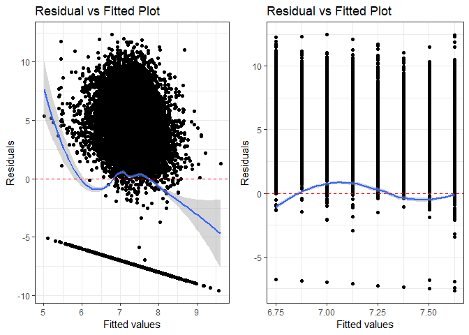

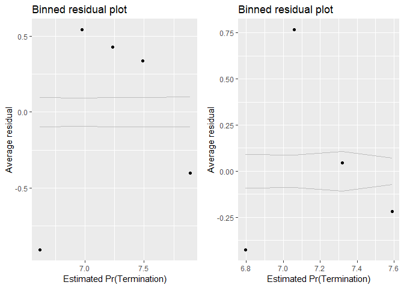

```r
summary_residual_compare(n_Opt_02D,n_Opt_03A, skip_vif = TRUE)
```